# **UK_traffic_and_accident_analysis**

Mukesh Shirke

2025-05-20

# **Introduction**

The UK Road Accident Analysis project investigates patterns and factors contributing to road accidents across the United Kingdom. Using official accident records, this analysis aims to uncover insights that can help policymakers, urban planners, and the public understand when, where, and under what conditions accidents are most likely to occur.

# **Scenario**

Road safety is a significant concern in the UK, with thousands of accidents occurring annually. Understanding the factors that influence accident frequency and severity—such as road type, weather, time of day, and junction layout—can inform targeted interventions. The current dataset provides detailed information on each accident, including location, road class, weather, light conditions, and accident severity.

# **Step 1: ASK**

### **Business Task**

What are the key factors associated with road accident frequency and severity in the UK, and how do these factors vary by road class, time, junction type, weather, and road surface conditions?

### **Key Questions**

**1. Which road classes and junction types are most prone to accidents?**  
**2. How do accident patterns vary by day of week and time of day?**  
**3. What is the relationship between weather/road surface conditions and accident severity?**  
**4. Are there specific conditions or locations where severe accidents are more likely?**

# **Step 2: PREPARE & PROCESS**

### **Data Selection**

This analysis uses the UK Road Safety - Accidents and Vehicles dataset from Kaggle, contributed by Tsiaras and licensed under the Open Government Licence v3.0. Visit UK Road Safety dataset on Kaggle

The dataset contains detailed records of UK road accidents reported between 2005 and 2017, including accident details, involved vehicles, and casualties. It consists of two main CSV files:  
**Accidents.csv:** Contains details of each accident, such as date, time, location, weather conditions, and accident severity.  
**Vehicles.csv:** Provides information about each vehicle involved in the accidents, including vehicle type, age, maneuver, and impact point.

These files provide comprehensive data for analyzing road safety trends and factors affecting accidents across the UK.

### **Limitations of this Data**

• **Missing Data:** Some fields, like junction details and location, are often missing or marked as “data missing or out of range.”  
• **Underreporting:** Only police-reported accidents are included, so minor incidents may be missed.  
• **No Direct Causes:** The data describes circumstances but not the exact causes of accidents.  
• **Outdated Coverage:** Data stops at 2017, so recent trends aren’t captured.  
• **Data Quality:** Possible errors or inconsistencies due to manual entry. • **Limited Detail:** Some categories (e.g., weather, road type) are broad, limiting fine-grained analysis.  
• **No Behavioral Data:** Lacks information on driver behavior, distractions, or vehicle telematics.

### **Environment**

**R Studio** was used to complete this analysis because it has many excellent data processing and visualization features.

**Install packages**

```r
# Package names
packages <- c(
            "tidyverse",
            "here",
            "knitr", "rmarkdown",
            "ggplot2", "dplyr", "tidyr", "janitor",
            "lubridate",
            "todor","lintr",
            "DT", "kableExtra",
            "roxygen2", "testthat", "scales",
            "ggpubr"
          )

#Install packages not yet installed
installed_packages <- packages %in% rownames(installed.packages())
if (any(installed_packages == FALSE)) {
  install.packages(packages[!installed_packages])
}

# Packages loading
lapply(packages, library, character.only = TRUE) |>
  invisible()
```

**Set Working Directory**

```r
getwd()
```

**Import Data**

For this analysis, I imported one key datasets:  
• Accidents.csv

```r
accidents <- read.csv("Accident_Information.csv", header = TRUE, sep = ",")
```

**Preview and Understand Data Structure**

```r
str(accidents)
head(accidents)
str(accidents)
glimpse(accidents)
summary(accidents)
```

### **Problems Identified in the Data**

• **Missing and Incomplete Data**: Several fields, such as Junction_Control, LSOA_of_Accident_Location, and some location coordinates, contain missing or “Data missing or out of range” values. This limits the completeness and reliability of analyses that rely on these fields.

• **Inconsistent Data Formats**: While most date and time fields are consistent, some categorical fields (e.g., 1st_Road_Class, 2nd_Road_Class) use different labels or have “Unclassified” entries, which may require standardization.

• **Potential Duplicate Records**: There may be duplicate accident entries, particularly if the same accident is recorded with slight variations. This could skew summary statistics if not addressed.

• **Mismatched Data Types**: Some key columns, such as road numbers, may be stored as numeric in some cases and as character in others, which can cause issues during data merging or filtering.

• **Ambiguous or Broad Categories**: Certain columns, such as Special_Conditions_at_Site or Weather_Conditions, include broad or ambiguous categories (e.g., “None,” “Unknown”), which may mask important details.

• **Outliers and Data Entry Errors**: Unusual or out-of-range values (such as “Data missing or out of range” for junction details) suggest possible data entry errors that need to be checked.

### **Data Cleaning**

**Standardize Column Names**

```r
accidents <- clean_names(accidents)
colnames(accidents)
```

```r
accidents <- accidents %>%
  rename(
    first_road_class = `x1st_road_class`,
    first_road_number = `x1st_road_number`,
    second_road_class = `x2nd_road_class`,
    second_road_number = `x2nd_road_number`
  )
```

**Verify uniqueness of accident_index**

```r
# Count the number of duplicated Accident_Index values
num_duplicates <- sum(duplicated(accidents$accident_index))
cat("Number of duplicated Accident_Index values:", num_duplicates, "\n")
```

```
## Number of duplicated Accident_Index values: 0
```

```r
library(dplyr)

# Remove duplicated Accident_Index rows, keeping only the first occurrence
accidents_no_duplicates <- accidents %>%
  distinct(accident_index, .keep_all = TRUE)

# If you want to overwrite the original data frame
accidents <- accidents_no_duplicates

#Check that duplicates are gone
sum(duplicated(accidents$Accident_Index))
```

```
## [1] 0
```

# **Step 3: ANALYSE & SHARE**

### **3.1 Temporal Patterns:**

### Top 25 Class A roads with highest accident counts

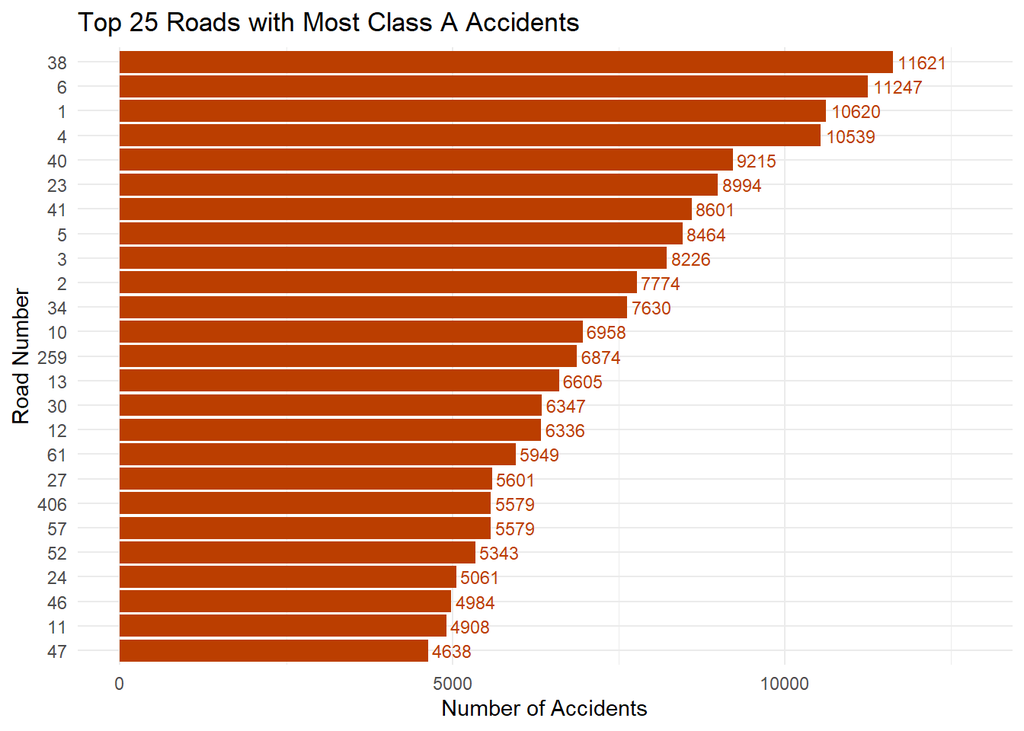

```r
# Filter only Class A accidents
class_a_accidents <- accidents %>%
  filter(first_road_class == "A")

# Count number of accidents per road number
road_counts <- class_a_accidents %>%
  group_by(first_road_number) %>%
  summarise(accident_count = n()) %>%
  arrange(desc(accident_count))

# Get top 25 roads with highest accident counts
top25_roads <- road_counts %>%
  slice_max(order_by = accident_count, n = 25)

# Create the bar chart
library(ggplot2)

ggplot(top25_roads, aes(x = reorder(as.factor(first_road_number), accident_count), y = accident_count)) +
  geom_bar(stat = "identity", fill = "#BB3E00") +
  geom_text(aes(label = accident_count),
            hjust = -0.1,           # Adjusts the position of the label
            size = 3.0,
            color = "#BB3E00") +
  coord_flip() +
  labs(
    title = "Top 25 Roads with Most Class A Accidents",
    x = "Road Number",
    y = "Number of Accidents"
  ) +
  theme_minimal() +
  ylim(0, max(top25_roads$accident_count) * 1.1)  # Adds some space for the labels
```

**Conclusion:**  
The analysis identified the top 25 roads with the highest number of accidents on roads classified as ‘A’. The results show that a small subset of ‘A’ roads accounts for a disproportionately high number of accidents compared to others. This concentration suggests that certain ‘A’ roads may have specific risk factors—such as higher traffic volumes, complex intersections, or challenging road layouts—that contribute to increased accident frequency.

### Accident frequency by day of week for Road Class

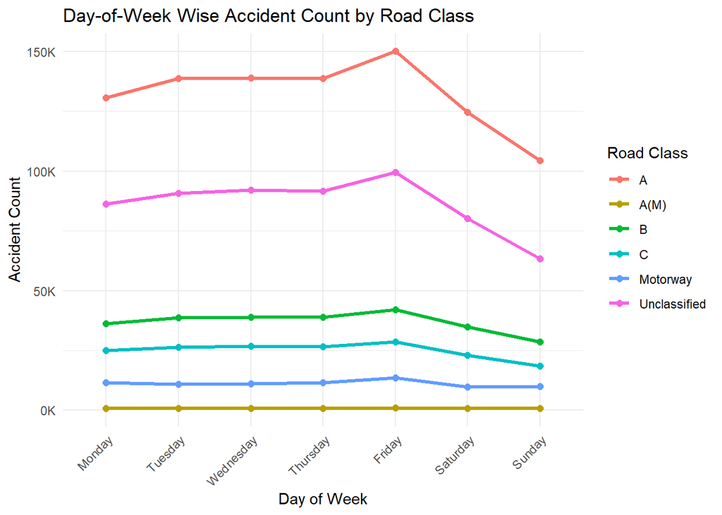

```r
# Ensure day_of_week is a factor with correct order
accidents <- accidents %>%
  mutate(
    day_of_week = factor(day_of_week,
                         levels = c("Monday", "Tuesday", "Wednesday", "Thursday", "Friday", "Saturday", "Sunday"),
                         ordered = TRUE),
    first_road_class = as.factor(first_road_class)
  )

accident_counts <- accidents %>%
  group_by(first_road_class, day_of_week) %>%
  summarise(count = n(), .groups = "drop")

# Line plot

library(scales)
ggplot(accident_counts, aes(x = day_of_week, y = count, color = first_road_class, group = first_road_class)) +
  geom_line(linewidth = 1.2) +   # <-- use linewidth instead of size
  geom_point(size = 2) +
  labs(
    title = "Day-of-Week Wise Accident Count by Road Class",
    x = "Day of Week",
    y = "Accident Count",
    color = "Road Class"
  ) +
  theme_minimal() +
  theme(axis.text.x = element_text(angle = 45, hjust = 1)) +
  scale_y_continuous(labels = label_number(scale = 0.001, suffix = "K"))
```

**Peak Accident Frequency for Class ‘A’ Roads Observed on Fridays**

```r
# Filter and count
num_a_friday <- sum(accidents$`first_road_class` == "A" & accidents$day_of_week == "Friday", na.rm = TRUE)

cat("Number of accidents where first_road_class is 'A' and Day_of_Week is 'Friday':", num_a_friday, "\n")
```

```
## Number of accidents where first_road_class is 'A' and Day_of_Week is 'Friday': 150248
```

### Accident frequency by hour for Road Class

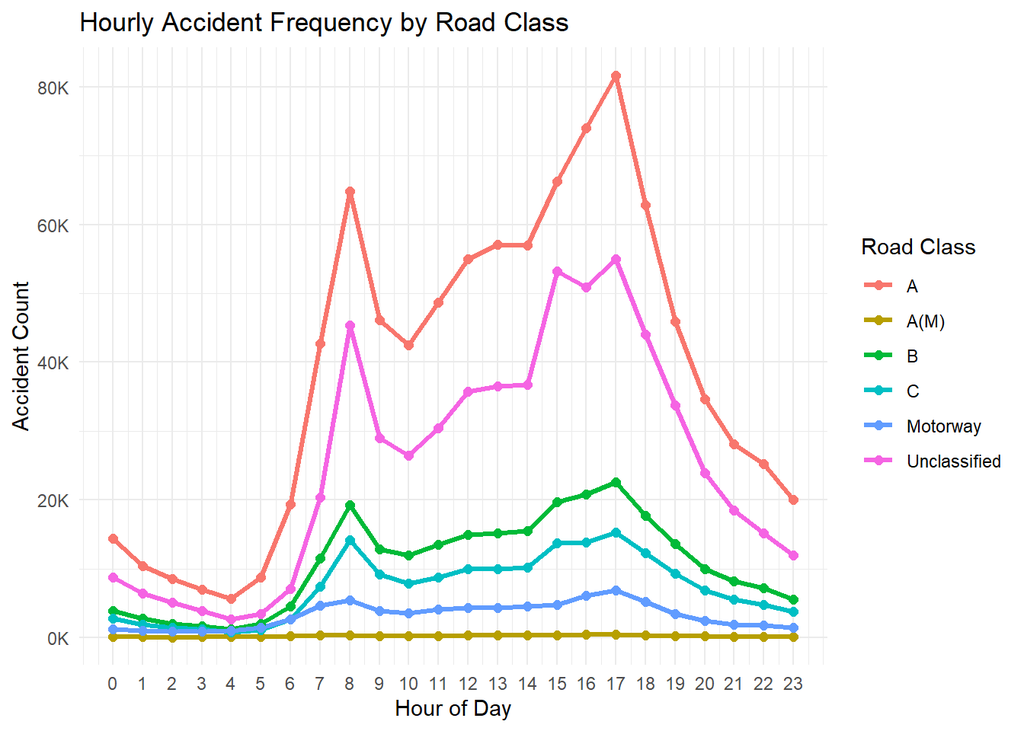

```r
# Extract hour from the time column, handling missing/malformed values
accidents <- accidents %>%
  mutate(
    hour = as.numeric(str_sub(time, 1, 2)),
    first_road_class = as.factor(first_road_class)
  ) %>%
  filter(!is.na(hour) & hour >= 0 & hour <= 23)

# Count accidents by road class and hour
accident_counts_hour <- accidents %>%
  group_by(first_road_class, hour) %>%
  summarise(count = n(), .groups = "drop")

# Line plot
ggplot(accident_counts_hour, aes(x = hour, y = count, color = first_road_class, group = first_road_class)) +
  geom_line(size = 1.2) +
  geom_point(size = 2) +
  labs(
    title = "Hourly Accident Frequency by Road Class",
    x = "Hour of Day",
    y = "Accident Count",
    color = "Road Class"
  ) +
  scale_x_continuous(breaks = 0:23) +
  theme_minimal() +
  theme(axis.text.x = element_text(angle = 0, hjust = 0.5)) +
  scale_y_continuous(labels = label_number(scale = 0.001, suffix = "K"))
```

**Conclusion:**  
The hourly analysis of accident frequency across different road classes reveals clear temporal patterns in road safety risks. Most road classes exhibit distinct peaks in accident counts during specific hours of the day, often corresponding to morning and evening rush hours. For example, higher accident frequencies are typically observed between 7–9 AM and 4–7 PM, aligning with periods of increased traffic volume due to commuting. The patterns may vary in magnitude and timing between different road classes, suggesting that the type of road influences when accidents are most likely to occur.

### Accident frequency by hour on Friday

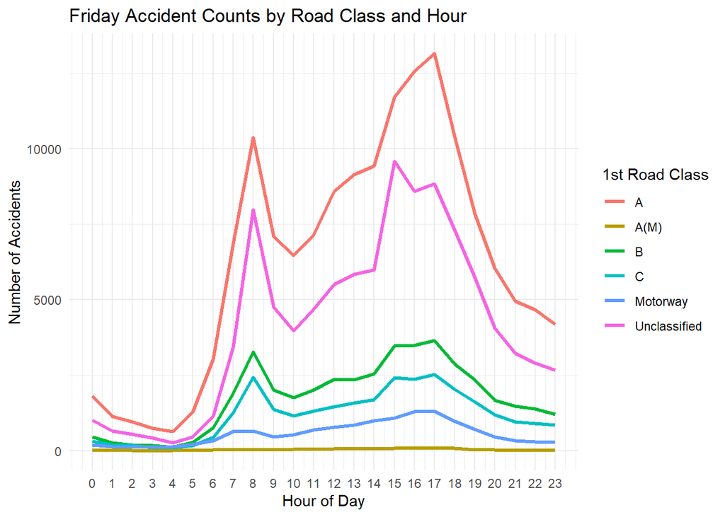

```r
# Filter for Friday
friday_accidents <- accidents %>%
  filter(day_of_week == "Friday")

# Safely extract hour from Time (handles missing or malformed times)
friday_accidents <- friday_accidents %>%
  mutate(
    Hour = as.numeric(str_sub(time, 1, 2)),
    Hour = ifelse(is.na(Hour) | Hour < 0 | Hour > 23, NA, Hour)
  ) %>%
  filter(!is.na(Hour))

# Count accidents by 1st_Road_Class and Hour
accident_counts <- friday_accidents %>%
  group_by(`first_road_class`, Hour) %>%
  summarise(Count = n(), .groups = "drop")

# Plot line graph
ggplot(accident_counts, aes(x = Hour, y = Count, color = `first_road_class`)) +
  geom_line(size = 1.2) +
  labs(
    title = "Friday Accident Counts by Road Class and Hour",
    x = "Hour of Day",
    y = "Number of Accidents",
    color = "1st Road Class"
  ) +
  scale_x_continuous(breaks = 0:23) +
  theme_minimal()
```

**Conclusion:**  
The analysis of accident frequency by hour on Fridays reveals pronounced temporal trends across different road classes. Accident counts tend to peak during specific hours, particularly aligning with morning and evening rush periods. For most road classes, there is a noticeable increase in accidents during the late afternoon and early evening, likely corresponding to increased traffic volumes as people commute home from work or school. Some road classes may also show elevated accident rates in the late evening, possibly reflecting social or leisure travel.

### **3.2 Road Class & Junction Detail:**

• Bar charts revealed higher accident counts on certain road classes (e.g., Class A) and at specific junction types (e.g., roundabouts, crossroads).

### Accident Counts by Road Class

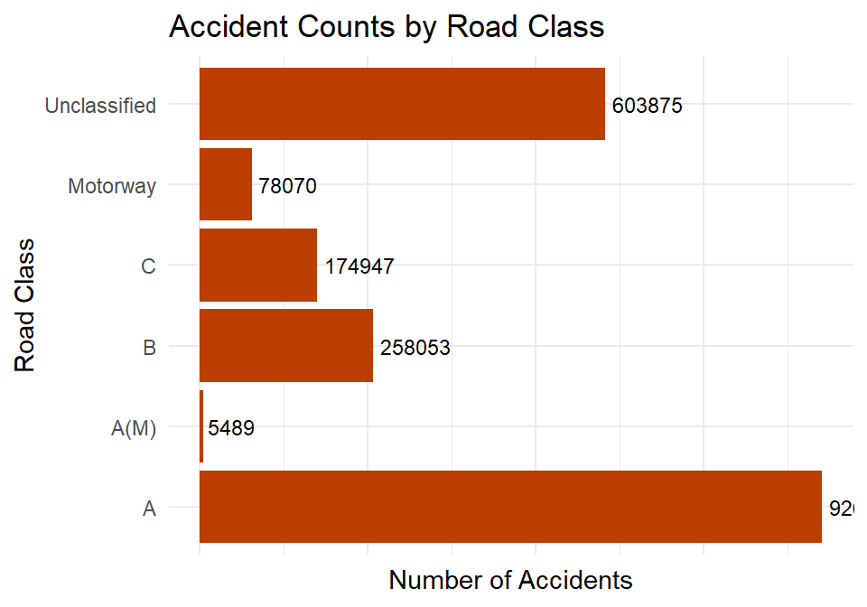

```r
# Count accidents by road class
road_class_counts <- accidents %>%
  group_by(`first_road_class`) %>%
  summarise(Count = n())

# Bar chart with reversed axes, adjusted labels, and hidden x-axis numbers
ggplot(road_class_counts, aes(y = `first_road_class`, x = Count)) +
  geom_bar(stat = "identity", fill = "#BB3E00") +
  geom_text(aes(label = Count), hjust = -0.1, color = "black", size = 3) +
  labs(
    title = "Accident Counts by Road Class",
    y = "Road Class",
    x = "Number of Accidents"
  ) +
  theme_minimal() +
  theme(legend.position = "none") +
  xlim(0, max(road_class_counts$Count) * 1.1) +
  scale_x_continuous(labels = NULL)
```

**Conclusion:**  
The analysis of accident counts by road class demonstrates that certain road classes experience significantly higher numbers of accidents compared to others. In your dataset, ‘A’ class roads and ‘Unclassified’ roads appear to have the highest accident frequencies, while ‘B’ and ‘C’ class roads show comparatively lower counts. This suggests that major roads (such as ‘A’ roads) and roads that are not formally classified are more prone to accidents, possibly due to higher traffic volumes, greater exposure, or less consistent road management.

###Accident Counts by Junction Type

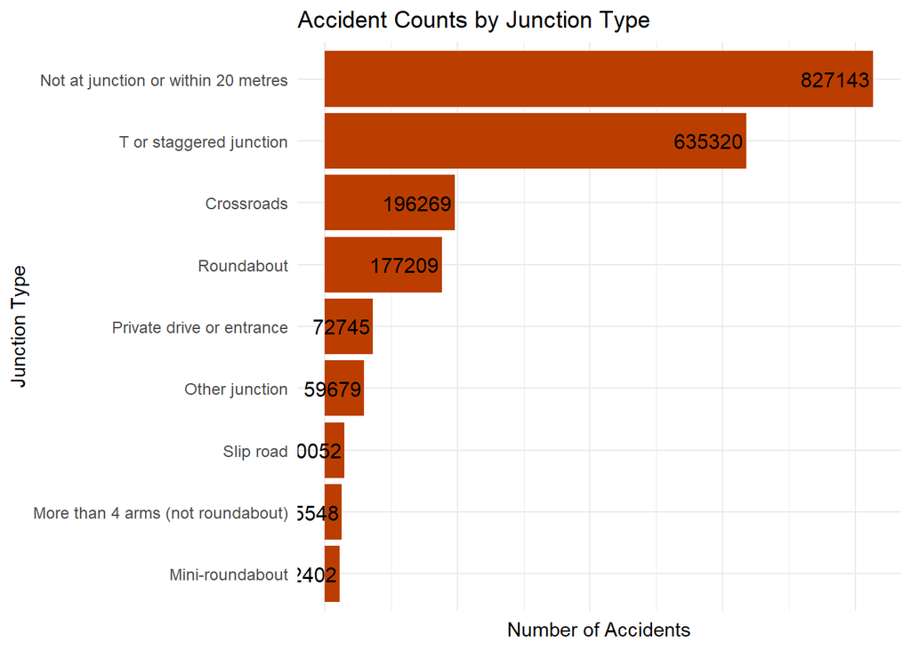

```r
# Exclude 'Data missing or out of range' and Count accidents by junction type

junction_type_counts <- accidents %>%
  filter(junction_detail != "Data missing or out of range") %>%
  group_by(junction_detail) %>%
  summarise(Count = n()) %>%
  arrange(desc(Count))

# Bar chart with reversed axis and hidden scale numbers

ggplot(junction_type_counts, aes(x = reorder(junction_detail, Count), y = Count)) +
  geom_bar(stat = "identity", fill = "#BB3E00") +
  geom_text(aes(label = Count), hjust = 1.05, color = "black", size = 4) +
  coord_flip() +
  labs(
    title = "Accident Counts by Junction Type",
    x = "Junction Type",
    y = "Number of Accidents"
  ) +
  theme_minimal() +
  theme(
    legend.position = "none",
    axis.text.y = element_text(size = 9), # smaller y-axis labels
    axis.text.x = element_blank(),        # hide x-axis tick labels (count axis)
    axis.ticks.x = element_blank()        # hide x-axis ticks
  )
```

**Conclusion:**  
The analysis of accident counts by junction type reveals that certain types of junctions are associated with a higher frequency of accidents. The most common categories, such as “Not at junction or within 20 metres,” “T or staggered junction,” and “Crossroads,” account for the majority of incidents. This suggests that both non-junction locations and specific junction configurations present distinct safety challenges. Notably, “T or staggered junctions” and “Crossroads” are particularly prone to accidents, likely due to the complexity of vehicle movements and increased potential for conflict between road users at these points.

### Accident Type by Junction Type and Road Class

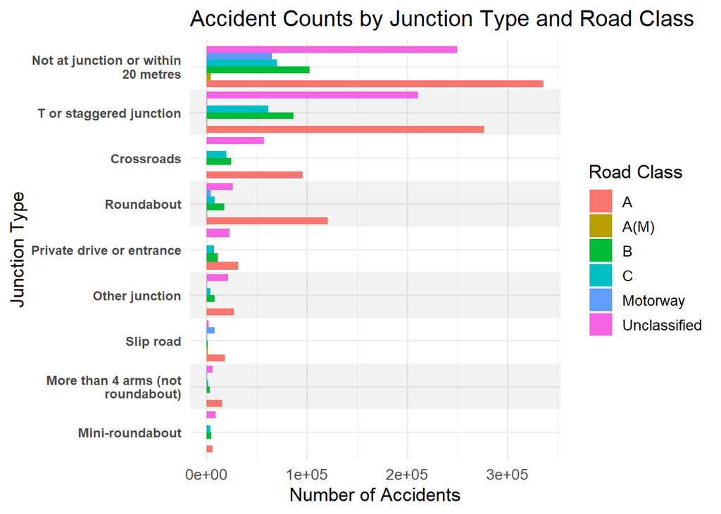

```r
# Exclude 'Data missing or out of range'
filtered_accidents <- accidents %>%
  filter(junction_detail != "Data missing or out of range")

# Summarize counts
junction_class_counts <- filtered_accidents %>%
  group_by(junction_detail, `first_road_class`) %>%
  summarise(Count = n(), .groups = "drop")

# Prepare for alternate highlighting
junction_levels <- junction_class_counts %>%
  group_by(junction_detail) %>%
  summarise(total = sum(Count)) %>%
  arrange(desc(total)) %>%
  mutate(row_id = row_number(),
         highlight = ifelse(row_id %% 2 == 0, "gray", "white"))

junction_class_counts <- left_join(junction_class_counts, junction_levels[, c("junction_detail", "row_id", "highlight")], by = "junction_detail")

# Plot
ggplot(junction_class_counts, aes(x = reorder(junction_detail, -row_id), y = Count, fill = `first_road_class`)) +
  # Add alternate background rectangles
  geom_rect(data = junction_levels,
            aes(ymin = -Inf, ymax = Inf, xmin = row_id - 0.5, xmax = row_id + 0.5, fill = NULL),
            inherit.aes = FALSE,
            fill = junction_levels$highlight,
            alpha = 0.2) +
  geom_bar(stat = "identity", position = position_dodge(width = 0.9)) +
  scale_x_discrete(labels = function(x) stringr::str_wrap(x, width = 25)) + # Wrap long labels
  labs(
    title = "Accident Counts by Junction Type and Road Class",
    x = "Junction Type",
    y = "Number of Accidents",
    fill = "Road Class"
  ) +
  theme_minimal(base_size = 13) +
  theme(
    axis.text.y = element_text(size = 9, face = "bold"),
    legend.position = "right"
  ) +
  coord_flip()
```

**Conclusion:**  
The analysis of accident counts by junction type and road class reveals that the distribution of accidents is not uniform across different junction configurations or road classes. Certain junction types—such as “T or staggered junctions” and “Crossroads”—consistently show higher accident frequencies, particularly for major road classes like ‘A’ and ‘Unclassified’. In contrast, some junction types see fewer accidents or are more closely associated with minor road classes. The alternating highlight in the plot further emphasizes these differences, making it clear which combinations of junction type and road class are most at risk.

### **3.3 Severity Analysis:**

• Grouped bar charts showed which conditions (weather, road surface, light) are associated with more severe accidents.

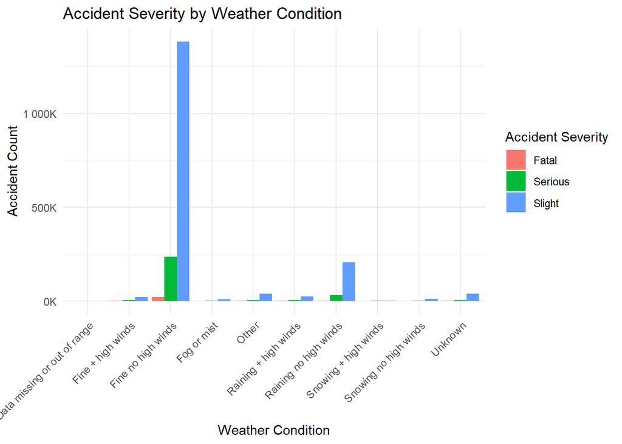

```r
library(scales)

# 1. Grouped bar chart: Weather_conditions vs Accident_severity

weather_conditions_accident_severity <- accidents %>%
  filter(!is.na(weather_conditions), !is.na(accident_severity)) %>%
  group_by(weather_conditions, accident_severity) %>%
  summarise(count = n(), .groups = "drop")

ggplot(weather_conditions_accident_severity, aes(x = weather_conditions, y = count, fill = accident_severity)) +
  geom_bar(stat = "identity", position = "dodge") +
  labs(
    title = "Accident Severity by Weather Condition",
    x = "Weather Condition",
    y = "Accident Count",
    fill = "Accident Severity"
  ) +
  theme_minimal() +
  theme(axis.text.x = element_text(angle = 45, hjust = 1)) +
  scale_y_continuous(labels = label_number(scale = 0.001, suffix = "K"))
```

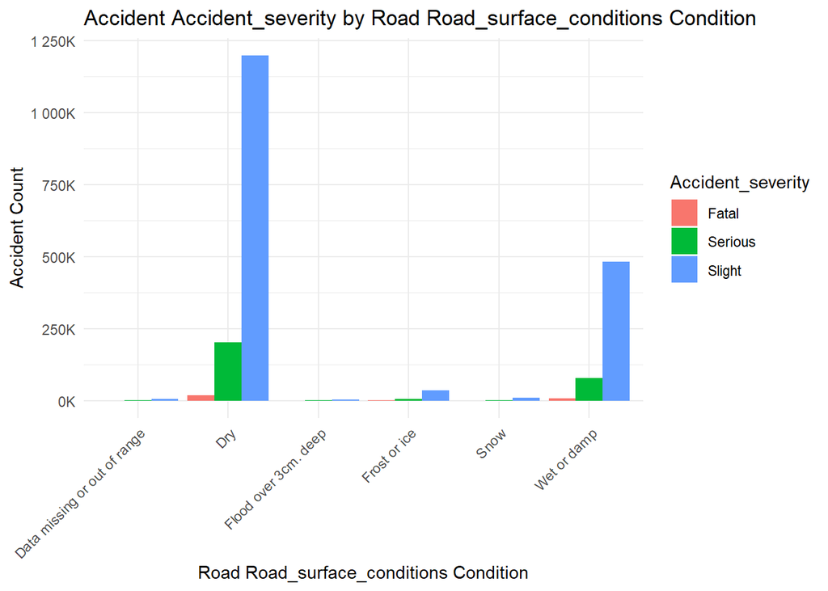

```r
# 2. Grouped bar chart: Road Road_surface_conditions vs Accident_severity

road_surface_conditions_accident_severity <- accidents %>%
  filter(!is.na(road_surface_conditions), !is.na(accident_severity)) %>%
  group_by(road_surface_conditions, accident_severity) %>%
  summarise(count = n(), .groups = "drop")

ggplot(road_surface_conditions_accident_severity, aes(x = road_surface_conditions, y = count, fill = accident_severity)) +
  geom_bar(stat = "identity", position = "dodge") +
  labs(
    title = "Accident Accident_severity by Road Road_surface_conditions Condition",
    x = "Road Road_surface_conditions Condition",
    y = "Accident Count",
    fill = "Accident_severity"
  ) +
  theme_minimal() +
  theme(axis.text.x = element_text(angle = 45, hjust = 1)) +
  scale_y_continuous(labels = label_number(scale = 0.001, suffix = "K"))
```

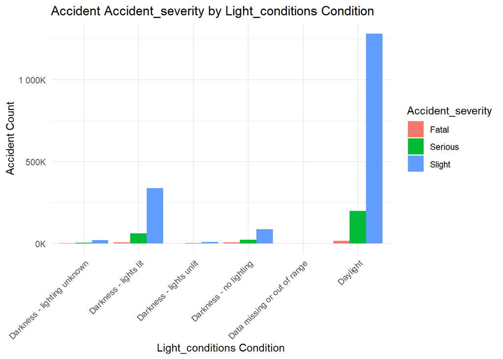

```r
# 3. Grouped bar chart: Light_conditions Condition vs Accident_severity

light_conditions_accident_severity <- accidents %>%
  filter(!is.na(light_conditions), !is.na(accident_severity)) %>%
  group_by(light_conditions, accident_severity) %>%
  summarise(count = n(), .groups = "drop")

ggplot(light_conditions_accident_severity, aes(x = light_conditions, y = count, fill = accident_severity)) +
  geom_bar(stat = "identity", position = "dodge") +
  labs(
    title = "Accident Accident_severity by Light_conditions Condition",
    x = "Light_conditions Condition",
    y = "Accident Count",
    fill = "Accident_severity"
  ) +
  theme_minimal() +
  theme(axis.text.x = element_text(angle = 45, hjust = 1)) +
  scale_y_continuous(labels = label_number(scale = 0.001, suffix = "K"))
```

### **3.4 Weather & Surface Conditions:**

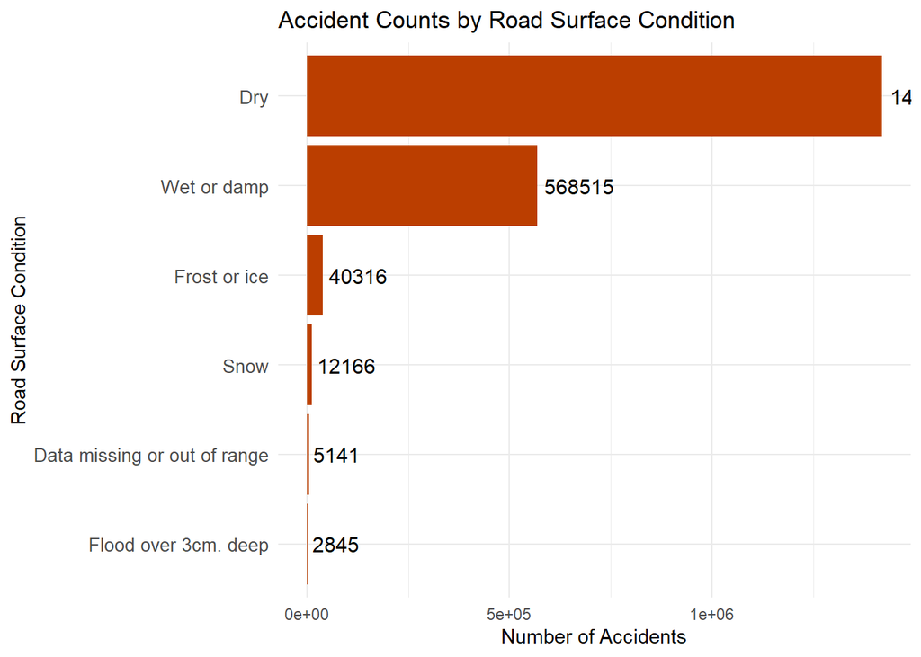

```r
# Bar chart: Accident count by Road Surface Condition
surface_counts <- accidents %>%
  group_by(road_surface_conditions) %>%
  summarise(Count = n(), .groups = "drop") %>%
  arrange(desc(Count))

ggplot(surface_counts, aes(x = reorder(road_surface_conditions, Count), y = Count)) +
  geom_bar(stat = "identity", fill = "#BB3E00") +
  geom_text(aes(label = Count), hjust = -0.1, color = "black", size = 4) +
  coord_flip() +
  labs(
    title = "Accident Counts by Road Surface Condition",
    x = "Road Surface Condition",
    y = "Number of Accidents"
  ) +
  theme_minimal() +
  theme(axis.text.y = element_text(size = 10))
```

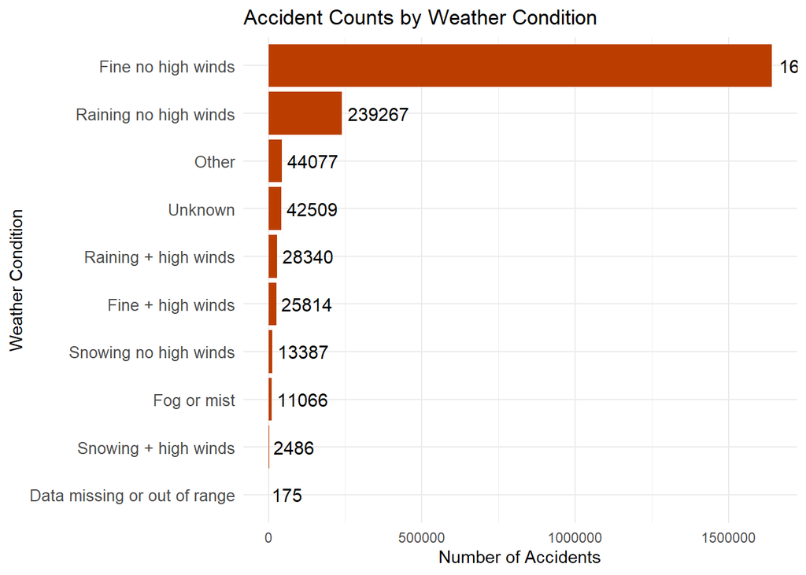

```r
# Bar chart: Accident count by Weather Condition
weather_counts <- accidents %>%
  group_by(weather_conditions) %>%
  summarise(Count = n(), .groups = "drop") %>%
  arrange(desc(Count))

ggplot(weather_counts, aes(x = reorder(weather_conditions, Count), y = Count)) +
  geom_bar(stat = "identity", fill = "#BB3E00") +
  geom_text(aes(label = Count), hjust = -0.1, color = "black", size = 4) +
  coord_flip() +
  labs(
    title = "Accident Counts by Weather Condition",
    x = "Weather Condition",
    y = "Number of Accidents"
  ) +
  theme_minimal() +
  theme(axis.text.y = element_text(size = 10))
```

### **Geographic Patterns:**

• Identified urban vs. rural accident trends.

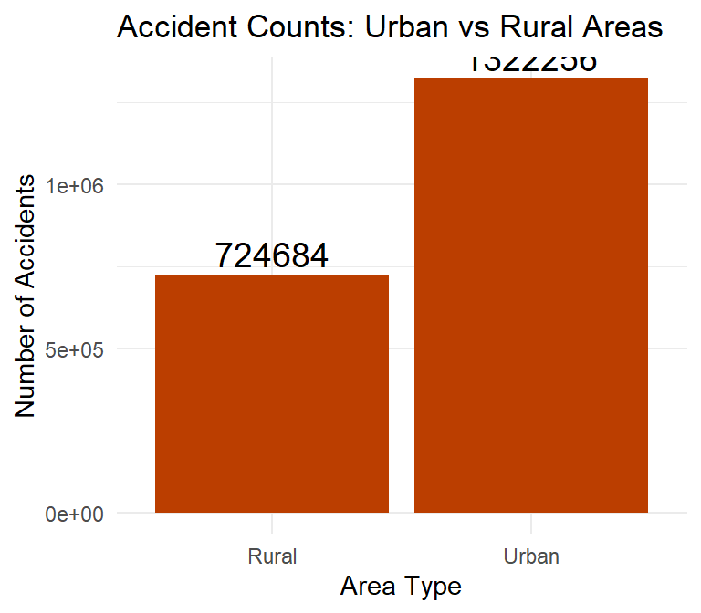

```r
# Exclude 'Unallocated' and Count accidents by Urban_or_Rural_Area
urban_rural_counts <- accidents %>%
  filter(!is.na(urban_or_rural_area), urban_or_rural_area != "Unallocated") %>%
  group_by(urban_or_rural_area) %>%
  summarise(Count = n(), .groups = "drop")

ggplot(urban_rural_counts, aes(x = urban_or_rural_area, y = Count)) +
  geom_bar(stat = "identity", fill = "#BB3E00") +
  geom_text(aes(label = Count), vjust = -0.3, color = "black", size = 5) +
  labs(
    title = "Accident Counts: Urban vs Rural Areas",
    x = "Area Type",
    y = "Number of Accidents"
  ) +
  theme_minimal()
```

**Conclusion**  
The comparison of accident counts between urban and rural areas reveals a significant geographic pattern: urban areas experience a much higher number of reported accidents than rural areas. This trend is consistent with the higher population density, greater vehicle and pedestrian traffic, and more complex road networks typically found in urban environments. However, while the absolute number of accidents is higher in urban areas, rural accidents may still be more severe due to higher average speeds and longer emergency response times.

# **Step 4: ACT**

### **Major Findings: Addressing Critical Questions**

**1. Which road classes and junction types are most prone to accidents?**  
**Analysis:**  
• The majority of accidents occur on **‘A’ class roads** and **Unclassified roads**. These roads likely see higher traffic volumes or more complex driving conditions.  
• For junctions, **“Not at junction or within 20 metres”** accounts for the largest number of accidents, followed by **“T or staggered junctions” and “Crossroads”**.  
• **Key Highlight:**  
> ‘A’ roads and unclassified roads are hotspots for accidents.  
> T-junctions and crossroads are the most accident-prone junction types.

**2. How do accident patterns vary by day of week and time of day?**  
**Analysis:**  
• **Friday** consistently records the highest number of accidents, especially for ‘A’ class roads.  
• Accidents peak during **morning (7–9 AM)** and **evening (4–7 PM)** rush hours, aligning with commuter traffic patterns.  
• **Key Highlight:**  
> Accident risk is highest on Fridays and during typical commuting hours, suggesting the need for targeted interventions at these times.

### **Key Insights & Recommendations**

• **Resource Allocation:**  
Focus enforcement and safety campaigns on ‘A’ roads, unclassified roads, and high-risk junctions, especially during Friday rush hours.

• **Infrastructure Improvements:**  
Prioritize upgrades (better lighting, signage, anti-skid surfaces) at accident-prone junctions and on roads with high accident severity.

• **Weather-Responsive Actions:**  
Deploy real-time alerts and increase patrols during adverse weather, especially on major roads and at night.

• **Targeted Education:**  
Run public awareness campaigns about the dangers of wet/icy roads, night driving, and high-risk junctions.